# ML-HW4

Brian Chang

2019/10/29

## Homework

1. Compare the most important features from at least 2 different classes of feature selection methods covered in this tutorial with any reasonable machine learning dataset from mlbench. Do these feature selection methods provide similar results?
2. Attempt a feature selection method not covered in this tutorial (backward elimination, forward propogation, etc.)

## Load Dataset

```r
data(PimaIndiansDiabetes)
indian <- as.data.frame(PimaIndiansDiabetes)
indian_num <- indian[,1:8]

indian_num = transform(indian_num, pregnant = as.numeric(pregnant),
                       glucose = as.numeric(glucose),
                       pressure = as.numeric(pressure),
                       triceps = as.numeric(triceps),
                       insulin = as.numeric(insulin),
                       mass = as.numeric(mass),
                       pedigree = as.numeric(pedigree),
                       age = as.numeric(age))
```

## Filter Method (Pearson’s Correlation)

- When threshold is set at 0.7, no variables were selected for.
- Lowered threshold to 0.5, which selects for only “age.”

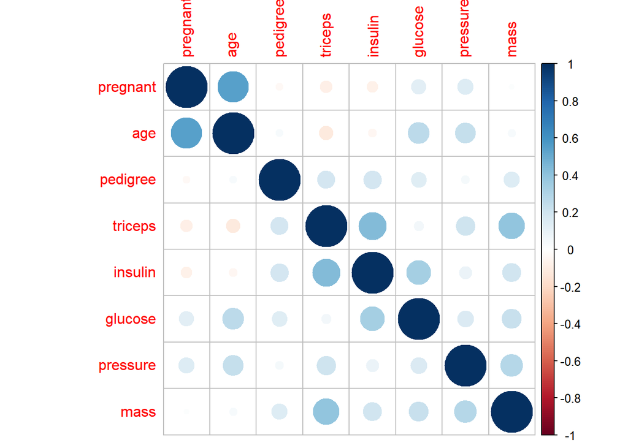

```r
# calculate correlation
correlation_matrix = cor(indian_num)

# correlation plot
library(corrplot)
corrplot(correlation_matrix, order = "hclust")
```

```r
# keep correlation >=0.7
highly_correlated <- colnames(indian)[findCorrelation(correlation_matrix, cutoff = 0.5, verbose = TRUE)]
```

```
## Compare row 8  and column  1 with corr  0.544
##   Means:  0.182 vs 0.175 so flagging column 8
## All correlations <= 0.5
```

```r
highly_correlated
```

```
## [1] "age"
```

## Wrapper Method (RFE)

- This method selects “age” as one of the top 3 variables. However, there are 2 others - “glucose” and “mass”
- This demonstrates similar results to the filter method as “age” is one of our selected variables.

```r
indian_num[is.na(indian_num)] = 0

#define the control
control = rfeControl(functions = caretFuncs, number = 2)

# run the RFE algorithm
results = rfe(indian[,1:8], indian[,9], sizes = c(2,3,5), rfeControl = control, method = "svmRadial")
# sizes is number of features you want to pull out

results
```

```
##
## Recursive feature selection
##
## Outer resampling method: Bootstrapped (2 reps)
##
## Resampling performance over subset size:
##
##  Variables Accuracy  Kappa AccuracySD   KappaSD Selected
##          2   0.7300 0.3883    0.03696 0.0687376
##          3   0.7509 0.4364    0.02217 0.0327578        *
##          5   0.7300 0.3927    0.04681 0.0853483
##          8   0.7369 0.4116    0.01232 0.0006134
##
## The top 3 variables (out of 3):
##    glucose, age, mass
```

```r
results$variables
```

```
##          neg       pos   Overall      var Variables  Resample
## 1  0.7921143 0.7921143 0.7921143  glucose         8 Resample1
## 2  0.6723766 0.6723766 0.6723766      age         8 Resample1
## 3  0.6722458 0.6722458 0.6722458     mass         8 Resample1
## 4  0.6110712 0.6110712 0.6110712 pregnant         8 Resample1
## 5  0.6049907 0.6049907 0.6049907 pedigree         8 Resample1
## 6  0.5834078 0.5834078 0.5834078 pressure         8 Resample1
## 7  0.5357197 0.5357197 0.5357197  triceps         8 Resample1
## 8  0.5101050 0.5101050 0.5101050  insulin         8 Resample1
## 9  0.7921143 0.7921143 0.7921143  glucose         5 Resample1
## 10 0.6723766 0.6723766 0.6723766      age         5 Resample1
## 11 0.6722458 0.6722458 0.6722458     mass         5 Resample1
## 12 0.6110712 0.6110712 0.6110712 pregnant         5 Resample1
## 13 0.6049907 0.6049907 0.6049907 pedigree         5 Resample1
## 14 0.7921143 0.7921143 0.7921143  glucose         3 Resample1
```

[output cut: 22 more lines]

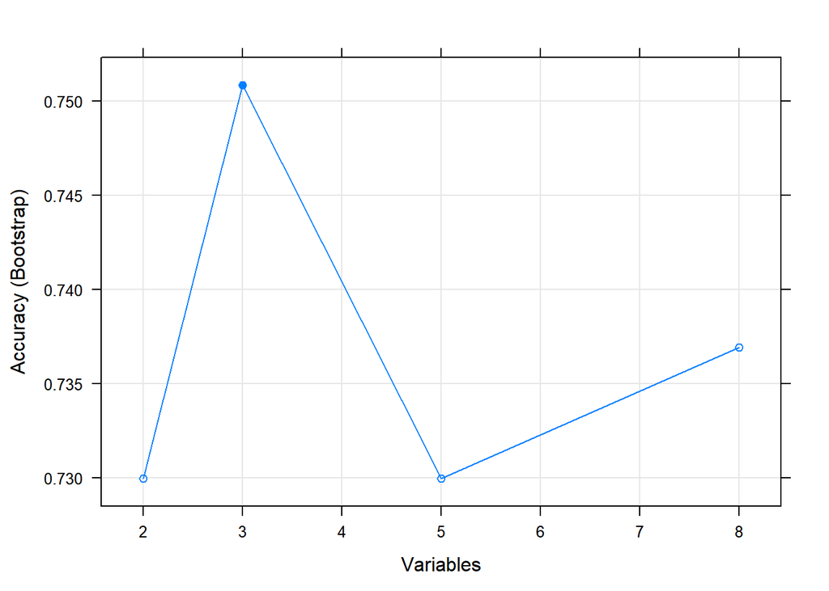

```r
plot(results, type=c('g','o'))
```

```r
predictors(results)
```

```
## [1] "glucose" "age"     "mass"
```

## Simulated Annealing

- We will fit a random forest model and run 10 iterations of the algorithm.
  - Only 10 iterations will be run for computational intensity.
- We see that the top 3 selected variables are - “glucose”, “age”, and “insulin” and “mass” being tied for third.
- The variables selected here are similar to the wrapper method earlier.

```r
sa_ctrl <- safsControl(functions = rfSA,
                       method = "repeatedcv",
                       repeats = 5,
                       improve = 50)
set.seed(10)
rf_sa <- safs(x = indian_num, y = indian[,9],
              iters = 10,
              safsControl = sa_ctrl)
rf_sa
```

```
##
## Simulated Annealing Feature Selection
##
## 768 samples
## 8 predictors
## 2 classes: 'neg', 'pos'
##
## Maximum search iterations: 10
## Restart after 50 iterations without improvement (0 restarts on average)
##
## Internal performance values: Accuracy, Kappa
## Subset selection driven to maximize internal Accuracy
##
## External performance values: Accuracy, Kappa
## Best iteration chose by maximizing external Accuracy
## External resampling method: Cross-Validated (10 fold, repeated 5 times)
##
## During resampling:
##   * the top 5 selected variables (out of a possible 8):
##     glucose (68%), age (62%), insulin (54%), mass (54%), pregnant (50%)
##   * on average, 3.9 variables were selected (min = 1, max = 7)
##
## In the final search using the entire training set:
##    * 2 features selected at iteration 5 including:
##      glucose, mass
##    * external performance at this iteration is
##
##    Accuracy       Kappa
##      0.7014      0.2994
```